# Lab 2 Team

Maureen McDonald

9/12/2019

```r
choco = read.csv("https://raw.githubusercontent.com/lbchu/ds202_labs/master/choco.csv")
head(choco)
```

```
##    Company Specific.Bean.Origin  REF Review.Date Cocoa.Pct
## 1 A. Morin          Agua Grande 1876        2016        63
## 2 A. Morin                Kpime 1676        2015        70
## 3 A. Morin               Panama 1011        2013        70
## 4 A. Morin           Madagascar 1011        2013        70
## 5 A. Morin               Brazil 1011        2013        70
## 6 A. Morin             Equateur 1011        2013        70
##   Company.Location Rating Bean.Type Broad.Bean.Origin
## 1           France   3.75                    Sao Tome
## 2           France   2.75                        Togo
## 3           France   2.75                      Panama
## 4           France   3.00   Criollo        Madagascar
## 5           France   3.25                      Brazil
## 6           France   3.75                     Ecuador
```

```r
recent_rating = choco[choco$Review.Date>2011,] #Creating a new list that shows only reviews dates from after 2011.

unique(recent_rating$Company.Location) # NOTICE: how many countries are listed but how many levels are there? #Locations of Companies that have review dates after 2011 without duplicates.

recent_rating$Company.Location = droplevels(recent_rating$Company.Location) #Dropping all the level before 2011.

head(recent_rating) #Gives you a preview of the recent ratings data set.

cross_table = table(recent_rating$Review.Date,recent_rating$Company.Location)
cross_table #Creates data table for Locations and dates after 2011 and counts how many reviews remained.

which(cross_table[1,]!=0 & cross_table[2,]!=0 & cross_table[3,]!=0 & cross_table[4,]!=0 & cross_table[5,]!=0) #Creates data table that doesn't show any Location that have zero review

france_recent = subset(recent_rating,Company.Location =='France') #Companies in France with rating made after 2011
uk_recent = subset(recent_rating,Company.Location =='U.K.') #Companies in UK with rating made after 2011.
germany_recent = subset(recent_rating,Company.Location=='Germany') #Companies in Germany with rating made after 2011

par(mfrow=c(2,2)) #combining multiple plots to fill in the matrix by columns
color1 = ifelse(france_recent$Rating >median(france_recent$Rating), 'blue', 'green') #Tells the graph that if the rating is higher than the median rating the color is blue, but if it is lower than the median than it is green
plot(france_recent$Cocoa.Pct ~ france_recent$Review.Date,ylim=c(50,90),col=color1,pch=18,cex=1.5,xlab="Review Date", ylab= "Cocoa Percentage", main= "France") #Creates scatter plot based off of values indicated- review date by cocoa percentages
legend('bottomright',legend=c('High Rating', 'Low Rating'),col=c('blue','green'),pch=18) #Shows the data that is being ploted by using a key to represent different data

color2 = ifelse(uk_recent$Rating >median(uk_recent$Rating), 'purple', 'red') #Tells the graph that if the rating is higher than the median rating the color is purple, but if it is lower than the median than it is red
plot(uk_recent$Cocoa.Pct ~ uk_recent$Review.Date,ylim=c(50,90),col=color2,pch=18,cex=1.5, xlab="Review Date", ylab= "Cocoa Percentage", main= "UK") #Creates scatter plot based off of values indicated- review date by cocoa percentages
legend('bottomright',legend=c('High Rating', 'Low Rating'),col=c('purple','red'),pch=18) #Shows the data that is being ploted by using a key to represent different data

color3 = ifelse(germany_recent$Rating > median(germany_recent$Rating), 'orange', 'yellow') #Tells the graph that if the rating is higher than the median rating the color is orange, but if it is lower than the median than it is yellow
plot(germany_recent$Cocoa.Pct ~ germany_recent$Review.Date,ylim=c(50,90),col=color3,pch=18,cex=1.5,xlab="Review Date", ylab= "Cocoa Percentage", main= "Germany") #Creates scatter plot based off of values indicated- review date by cocoa percentages
legend('bottomright',legend=c('High Rating', 'Low Rating'),col=c('orange','yellow'),pch=18) #Shows the data that is being ploted by using a key to represent different data
```

[output not shown]

2 . Click Zoom on the Rstudio window (under Plots) to see the plot more clearly. How do you think the plot produced from the code above can be improved? Recommend at least one possible improvement.

3 . How does the **number** of ratings (not the actual value of the rating) depend on the year? Use graphics to answer this question.

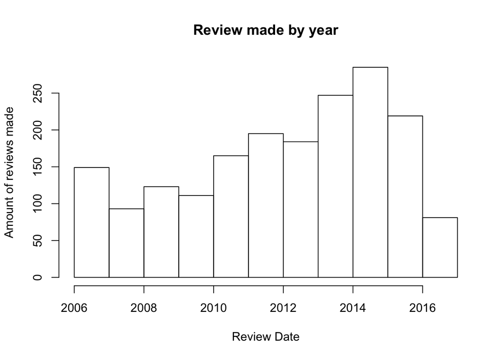

```r
hist(choco$Review.Date, main = "Review made by year", xlab = "Review Date", ylab= "Amount of reviews made")
```

4 . How do ratings compare across different company locations? Focus on the three locations with the most ratings. Hint: the function `sort()` might come in handy here.

```r
# USA, France, Canda

library(plotly)
p <- plot_ly(
  x= choco$Company.Location,
  y= choco$Rating,
  type= "bar"
)
p
```

[interactive chart not shown]

```r
# USA, France, Canada
# According to the plot above, the USA has much higher ratings than anywhere else in the world.
```

5 . Brainstorm and write down an interesting question that can be answer from the dataset. The question should not duplicate the questions above.

What is the mean rating of all countries?

6 . Bonus points (optional): Answer the question from the dataset.

```r
mean(choco$Rating)
```

```
## [1] 3.19101
```